# Exercise 7

Joe Endris

2023-10-23

## Chlorophyll Fluorescence

Light energy absorbed by a leaf can undergo one of three fates: it can be used to drive photosynthesis, dissipated as heat, or re-emitted as light — chlorophyll fluorescence. We measure chlorophyll fluorescence as a ratio F<sub>v</sub>/F<sub>m</sub>. We can use this measurement to investigate how stressors damage the photosynthetic apparatus.

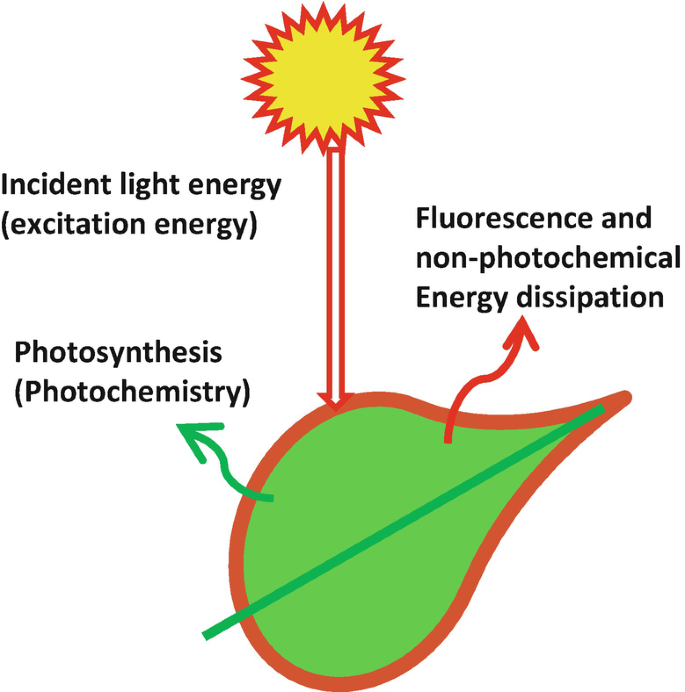

## Let’s look at a couple of plots

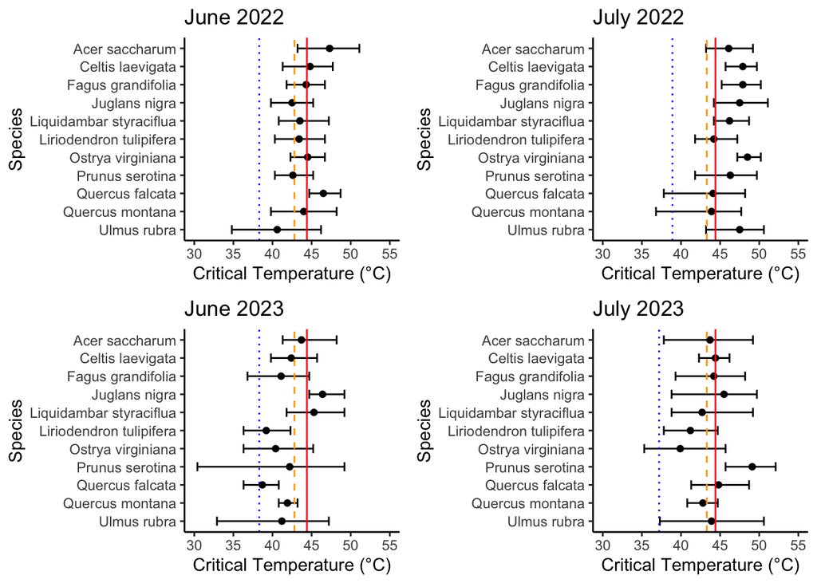

We can see the T<sub>crit</sub> for 11 species of trees found on the farm along with the all time record high temperature for Clarksville (red line), the hottest temperature for the respective month (orange line), and the highest temperature observed during the collection month (blue line).

## Co-linearity and correlation

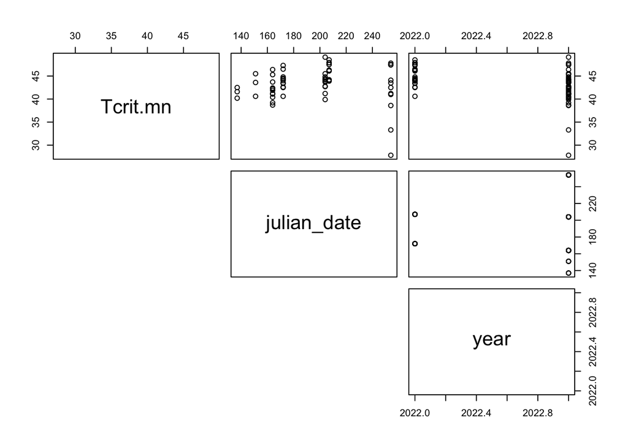

```
##             Tcrit.mn julian_date  year
## Tcrit.mn        1.00       -0.03 -0.38
## julian_date    -0.03        1.00  0.11
## year           -0.38        0.11  1.00
```

It does not appear there is any co-linearity among the variables.

## Global model

Now we can take a look at our global model.

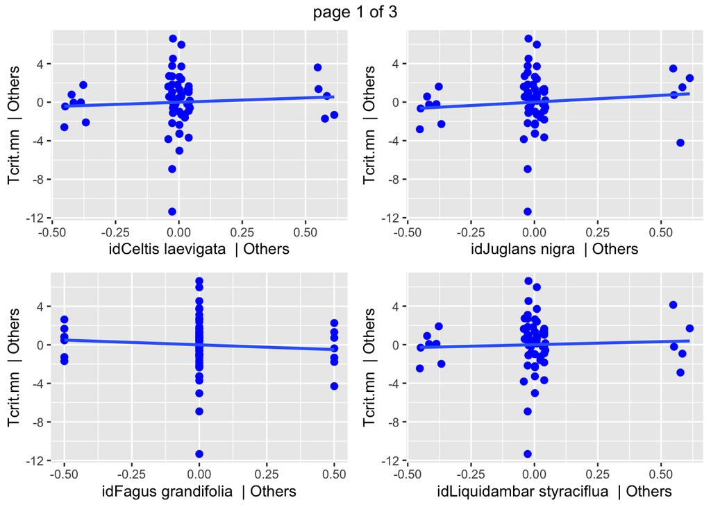

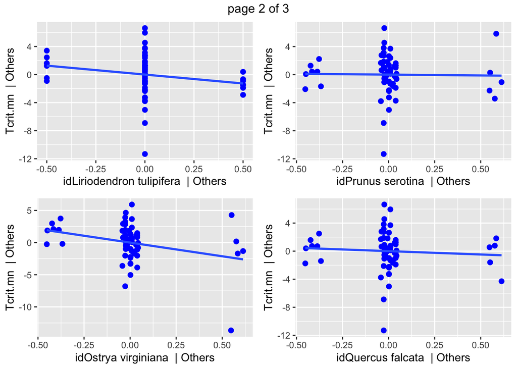

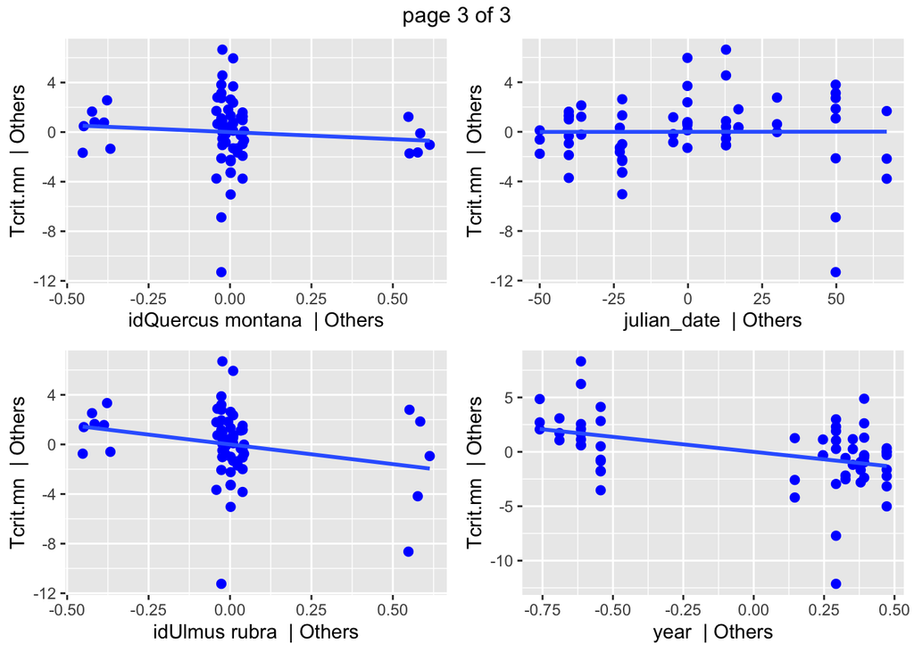

```
## Fixed term is "(Intercept)"
```

|  | (Intercept) | id | julian_date | year | df | logLik | AICc | delta | weight |
| --- | --- | --- | --- | --- | --- | --- | --- | --- | --- |
| 5 | 5689.58287 | NA | NA | -2.791492 | 3 | -158.6275 | 323.6760 | 0.000000 | 7.332492e-01 |
| 7 | 5709.36845 | NA | 0.0012237523 | -2.801392 | 4 | -158.6224 | 325.9591 | 2.283064 | 2.341480e-01 |
| 1 | 43.40164 | NA | NA | NA | 2 | -163.3937 | 330.9944 | 7.318332 | 1.888409e-02 |
| 3 | 44.01289 | NA | -0.0031398900 | NA | 3 | -163.3647 | 333.1505 | 9.474473 | 6.425336e-03 |
| 6 | 5616.61014 | + | NA | -2.754938 | 13 | -149.7579 | 333.2605 | 9.584464 | 6.081514e-03 |
| 8 | 5620.10873 | + | 0.0001743006 | -2.756684 | 14 | -149.7578 | 336.6460 | 12.969957 | 1.119080e-03 |
| 2 | 44.15714 | + | NA | NA | 12 | -155.7609 | 342.0218 | 18.345808 | 7.612195e-05 |
| 4 | 45.14073 | + | -0.0053414151 | NA | 13 | -155.6582 | 345.0611 | 21.385094 | 1.665473e-05 |

Now we can trim the list of models down to only models with a AIC delta of less than 5.

|  | (Intercept) | id | julian_date | year | df | logLik | AICc | delta | weight |
| --- | --- | --- | --- | --- | --- | --- | --- | --- | --- |
| 5 | 5689.583 | NA | NA | -2.791492 | 3 | -158.6275 | 323.6760 | 0.000000 | 0.7579608 |
| 7 | 5709.368 | NA | 0.001223752 | -2.801392 | 4 | -158.6224 | 325.9591 | 2.283064 | 0.2420392 |

```
##                      year  julian_date id
## Sum of weights:       0.97  0.24       <0.01
## N containing models:     4     4           4
```

```
## Fixed term is "(Intercept)"
```

|  | (Intercept) | id | julian_date | year | df | logLik | AICc | delta | weight |
| --- | --- | --- | --- | --- | --- | --- | --- | --- | --- |
| 5 | 5689.58287 | NA | NA | -2.791492 | 3 | -158.6275 | 323.6760 | 0.000000 | 0.738636308 |
| 7 | 5709.36845 | NA | 0.001223752 | -2.801392 | 4 | -158.6224 | 325.9591 | 2.283064 | 0.235868321 |
| 1 | 43.40164 | NA | NA | NA | 2 | -163.3937 | 330.9944 | 7.318332 | 0.019022829 |
| 3 | 44.01289 | NA | -0.003139890 | NA | 3 | -163.3647 | 333.1505 | 9.474473 | 0.006472542 |

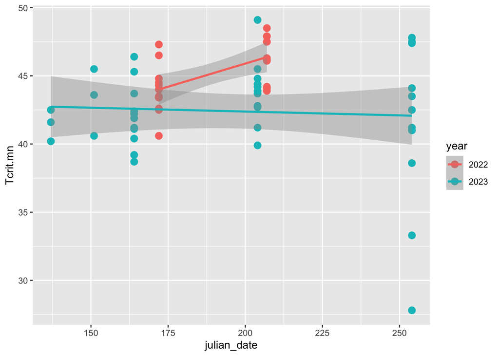

## On this day…

[figure not shown]

**Black Thursday that began the 1929 stock market crash and the Bloody Friday crash in 2008 both occurred!**